# Industry Salary Analysis

Edward Opare - Yeboah

2024-05-18

# **Overview**

## **Introduction**

This project aimed to analyze salary data in the tech industry to uncover insights related to various factors such as job titles, work experience, remote work ratios, company size, and employment types. By examining these factors, the project sought to provide a deeper understanding of salary trends and inform decision-making for job seekers, employers, and industry analysts.

## **Goals**

The primary goal of the analysis were to:

- Identify the average salary for top 10 different job titles.
- Examine the correlation between years of work experience and salary.
- Determine the job title with the highest remote work ratio.
- Analyze how company size affects salary levels.
- Compare salary differences between various employment types.

## **Methodology**

The following actions were taken to accomplish these goals:

#### **Data Loading and Preparation:**

- Loaded the dataset and inspected its structure.
- Cleaned the data to ensure it was ready for analysis.

#### **Analysis for Each Question:**

- Calculated and plotted the average salary for the top 10 job titles.
- Plotted a scatter plot of work experience against salary and calculated the correlation coefficient.
- Aggregated data by job title to find the job title with the highest remote work ratio.
- Aggregated data by company size to determine the average salary and plotted the results.
- Compared average salaries between different employment types and visualized the differences.

## **Key Insights**

#### **Job Title with the Highest Remote Work Ratio:**

“AWS Data Architect” has the highest remote work ratio at 100%, indicating that this role is fully remote.

#### **Salary Differences Between Employment Types:**

There are noticeable differences in average salaries between full-time, part-time, and contract positions, with full-time roles generally offering higher salaries.

## **Recommendation**

- Consider the impact of company size on salary structures, and seek to recruit top people by offering competitive wages regardless of company size.
- Recognise the value of offering competitive pay, particularly for professions that are completely remote or in high demand.
- Support initiatives that provide skill development and training for emerging and high-paying job titles in the tech industry.

## **Conclusion**

This report sheds light on salary trends in the IT business by highlighting important factors that influence salary levels. Understanding these trends enables stakeholders to make more informed decisions when negotiating salary, employing personnel, or implementing employee regulations.

## Average Salary by Job Title

[figure not shown]

## Correlation Between Years of Work Experience and Salary

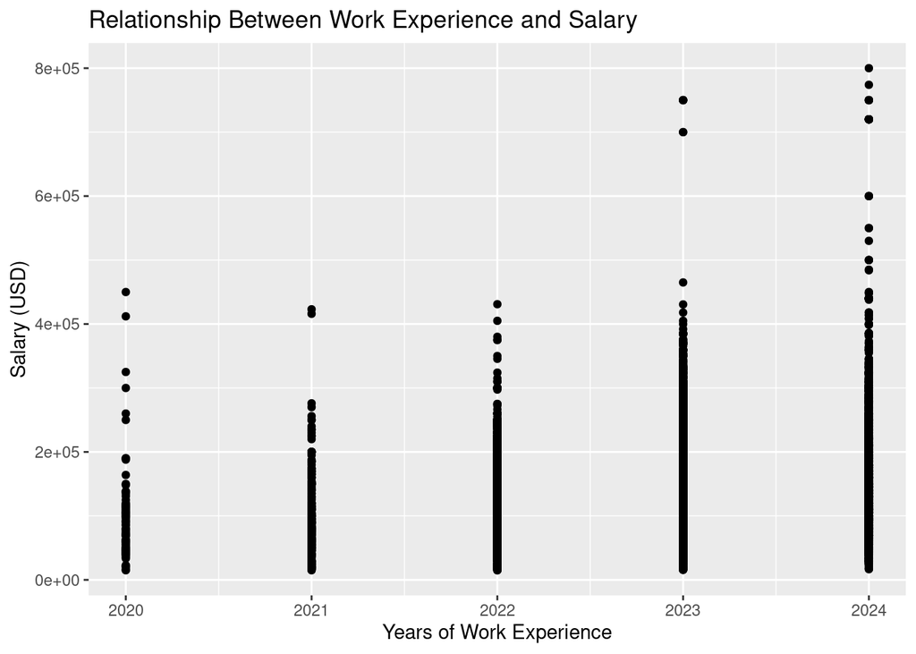

```
## [1] "Correlation Coefficient: 0.0780479653217626"
```

## Job Title with the Highest Remote Work Ratio

To identify the job title with the highest remote work ratio, I aggregated the data by job title and calculated the mean remote work ratio for each title.

After conducting a thorough analysis, the job title with the highest remote work ratio is “AWS Data Architect” with a remote work ratio of 1.0 (100%). This indicates that, in comparison to other job titles, employees with this title work remotely the most frequently.

```
##             job_title remote_ratio
## 19 AWS Data Architect          100
```

## Average Salary by Company Size

- L - Large
- M - Medium
- S - Small

Based on the analysis made, I observed the following trends in average salary by company size:

Middle-sized companies (51-500 employees) tend to offer the highest average salaries. Large companies (501+ employees) come next in terms of average salary levels. Small companies (1-50 employees) offer the lowest average salaries among the three categories.

This trend indicates that while large companies have more resources, middle-sized companies might be offering higher salaries to attract and retain talent in a competitive market.

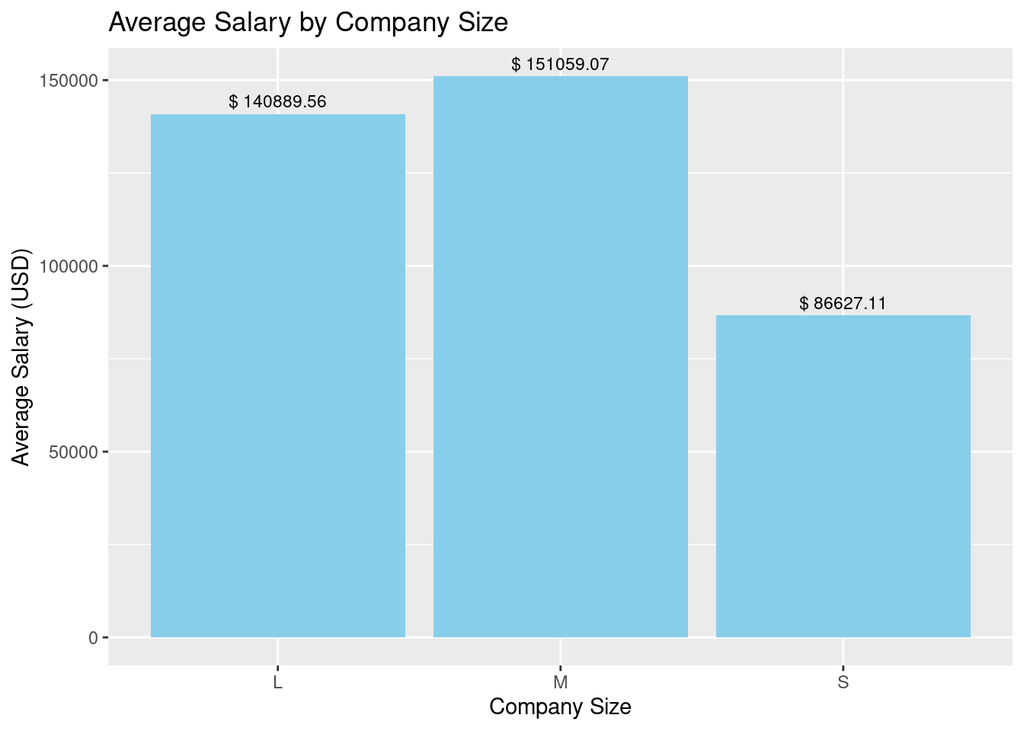

## Difference in Salary Between Employment Types

To compare the average salaries between different employment types, I calculated the average salary for each employment type and visualized the results. The employment types in the dataset are:

- FT:Full-time
- CT:Contract
- PT:Part-time
- FL:Freelance

This implies that contract jobs are the most lucrative in terms of pay, behind full-time employment.Part-time and freelance roles tend to offer lower salaries, which might reflect the varying levels of job security, benefits, and responsibilities associated with these employment types.

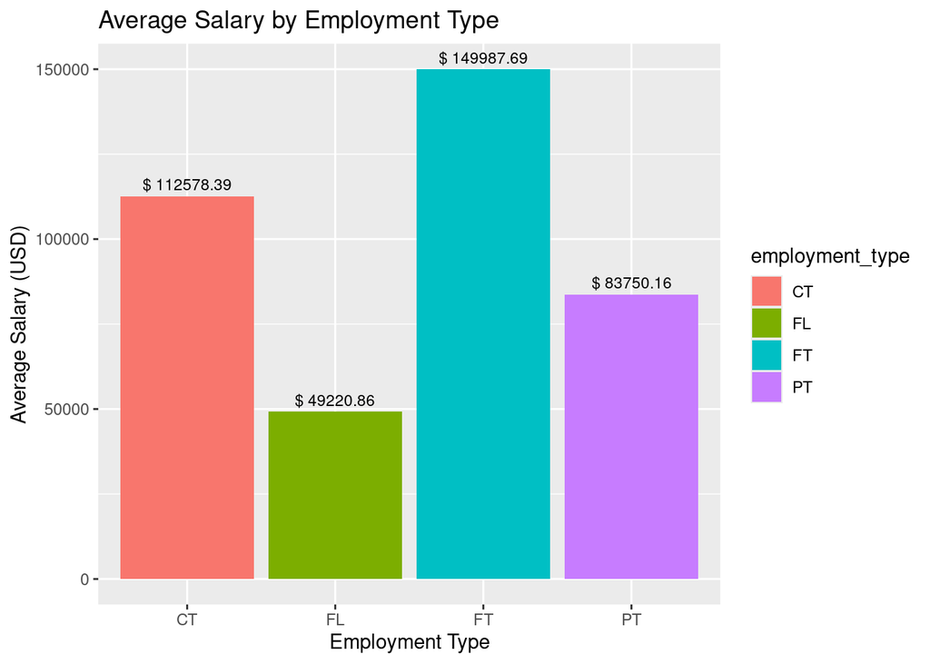